# 1. Loading Data

## 6.2 Modelling with filled values in Revenue.

**(for complete code please refer "Model_Experimentation.ipynb")**

```python
newdf = final_data[final_data['revenue'] != 0]
newdf_V2 = final_data[final_data['revenue'] == 0] #we are going to replace these zeros with prediction
X = newdf.drop('revenue', axis = 1)
y = newdf['revenue']
X_train, X_test, y_train, y_test = train_test_split(X, y, test_size=0.20, random_state=123)
## we are going to use this at the end.
final_check_X_test = X_test
final_check_y_test = y_test


## our best model is Bayesian Opimize XGBoost.
eval_set = [(X_test, y_test)]
def xgb_optimization(cv_splits, eval_set):
    def function(eta, gamma, max_depth,n_estimators,min_child_weight):
            return cross_val_score(
                   xgb.XGBRegressor(
                       n_estimators=int(max(n_estimators,50)),
                       objective="reg:linear",
                       learning_rate=max(eta, 0),
                       gamma=max(gamma, 0),
                       max_depth=max(int(max_depth), 1),
                       min_child_weight=max(min_child_weight, 1),
                       #subsample = max(subsample, 0),
                       #colsample_bytree = max(colsample_bytree, 0),
                       #colsample_bylevel = max(colsample_bylevel, 0),

                       seed=42,
                       nthread=-1
                       ),
                   X=X_train,
                   y=y_train,
                   cv=cv_splits,
                   scoring='neg_mean_squared_error',
                   fit_params={
                        "early_stopping_rounds": 200,
                        "eval_metric": "rmse",
                        "eval_set": eval_set},
                   n_jobs=-1).mean()

    parameters = {"eta": (0.07, 0.2),
                  "gamma": (0,2),
                  "max_depth": (1, 10),
                 "min_child_weight": (1, 10),
                 #"subsample": (0,1),
                 #"colsample_bytree": (0,1),
                  "n_estimators": (50,150),
                  #"colsample_bylevel": (0,1)

                 }

    return function, parameters

#Train model using optimum parameters
def xgbtrain(X_train, y_train, X_test, y_test, function, parameters):
    dataset = (X_train, y_train, X_test, y_test)
    cv_splits = 10

    best_solution = bayesian_optimization(dataset, function, parameters)
    params = best_solution["params"]

    model = XGBRegressor(
             n_estimators=int(params["n_estimators"]),
             objective="reg:linear",
             learning_rate= params["eta"],
             gamma=int(params["gamma"]),
             max_depth=int(params["max_depth"]),
             min_child_weight=int(params["min_child_weight"]),
             #subsample=int(params["subsample"]),
             #colsample_bytree=int(params["colsample_bytree"]),
             #colsample_bylevel = int(params["colsample_bylevel"]),
             nthread=-1,
             seed=42
             )

    model.fit(X_train, y_train)

    return model


xgbfunction, xgbparameters = xgb_optimization(10, eval_set)
xgbmodel =xgbtrain(X_train, y_train, X_test, y_test, xgbfunction, xgbparameters)
del eval_set

##filling zeros
X_test = newdf_V2.drop('revenue', axis = 1)
y_pred = xgbmodel.predict(X_test)
newdf_V2['revenue'] = y_pred
final_data2 = pd.concat([newdf, newdf_V2], ignore_index=True)

X = final_data2.drop('revenue', axis = 1)
y = final_data2['revenue']
X_train, X_test, y_train, y_test = train_test_split(X, y, test_size=0.20, random_state=123)
## we are going to use
X_test = final_check_X_test
y_test = final_check_y_test
```

```
|   iter    |  target   |    eta    |   gamma   | max_depth | min_ch... | n_esti... |
-------------------------------------------------------------------------------------
|  1        | -2.858    |  0.1289   |  0.441    |  1.49     |  6.883    |  112.8    |
|  2        | -2.79     |  0.1997   |  0.6764   |  4.662    |  2.167    |  66.72    |
|  3        | -2.876    |  0.1408   |  1.631    |  7.664    |  5.448    |  105.1    |
|  4        | -2.836    |  0.1864   |  0.3656   |  7.342    |  8.839    |  132.6    |
|  5        | -2.898    |  0.1422   |  0.264    |  8.82     |  5.914    |  85.26    |
|  6        | -2.675    |  0.1031   |  1.646    |  3.064    |  8.493    |  146.3    |
|  7        | -2.794    |  0.09539  |  1.593    |  6.434    |  9.995    |  130.8    |
|  8        | -2.899    |  0.1085   |  0.4476   |  1.563    |  8.228    |  87.54    |
|  9        | -2.854    |  0.1239   |  0.4786   |  8.529    |  7.644    |  70.62    |
|  10       | -2.885    |  0.07355  |  1.042    |  5.881    |  1.716    |  65.06    |
|  11       | -2.848    |  0.1146   |  0.1848   |  6.706    |  6.689    |  124.5    |
|  12       | -2.929    |  0.1659   |  0.9813   |  8.36     |  6.795    |  112.3    |
|  13       | -2.889    |  0.2      |  0.0      |  1.0      |  10.0     |  50.0     |
|  14       | -2.889    |  0.07     |  2.0      |  1.0      |  1.0      |  150.0    |
|  15       | -2.844    |  0.07     |  2.0      |  10.0     |  10.0     |  150.0    |
|  16       | -2.753    |  0.2      |  0.0      |  1.0      |  10.0     |  150.0    |
|  17       | -2.784    |  0.2      |  2.0      |  1.0      |  1.0      |  129.0    |
|  18       | -2.849    |  0.2      |  2.0      |  1.0      |  1.0      |  78.75    |
|  19       | -2.865    |  0.2      |  0.0      |  1.0      |  10.0     |  65.68    |
|  20       | -2.894    |  0.07     |  2.0      |  1.0      |  10.0     |  138.8    |
|  21       | -2.891    |  0.2      |  0.0      |  1.0      |  1.0      |  50.0     |
|  22       | -2.817    |  0.2      |  0.0      |  1.0      |  1.0      |  99.21    |
|  23       | -3.06     |  0.07     |  2.0      |  10.0     |  1.0      |  135.7    |
|  24       | -2.801    |  0.2      |  2.0      |  1.0      |  1.0      |  115.3    |
|  25       | -2.933    |  0.2      |  0.0      |  10.0     |  10.0     |  50.0     |
|  26       | -2.942    |  0.2      |  0.0      |  10.0     |  10.0     |  97.16    |
|  27       | -3.151    |  0.2      |  0.0      |  10.0     |  1.0      |  75.02    |
|  28       | -2.868    |  0.2      |  2.0      |  1.0      |  1.0      |  66.81    |
|  29       | -3.081    |  0.2      |  2.0      |  10.0     |  1.0      |  95.73    |
|  30       | -2.85     |  0.2      |  0.0      |  1.0      |  10.0     |  76.42    |
|  31       | -2.809    |  0.2      |  2.0      |  1.0      |  10.0     |  102.6    |
|  32       | -2.828    |  0.2      |  0.0      |  5.516    |  5.932    |  146.6    |
|  33       | -2.738    |  0.2      |  2.0      |  3.355    |  10.0     |  150.0    |
|  34       | -2.844    |  0.07     |  2.0      |  10.0     |  10.0     |  141.3    |
|  35       | -2.97     |  0.2      |  2.0      |  10.0     |  10.0     |  125.0    |
|  36       | -2.901    |  0.07     |  0.0      |  1.0      |  10.0     |  124.9    |
|  37       | -2.977    |  0.07     |  0.0      |  1.0      |  3.454    |  72.22    |
|  38       | -2.97     |  0.2      |  2.0      |  10.0     |  10.0     |  81.35    |
|  39       | -2.831    |  0.2      |  2.0      |  1.0      |  1.0      |  88.99    |
|  40       | -2.812    |  0.2      |  2.0      |  1.0      |  1.0      |  106.5    |
|  41       | -2.97     |  0.2      |  0.0      |  8.201    |  10.0     |  61.12    |
|  42       | -3.081    |  0.2      |  2.0      |  10.0     |  1.0      |  50.0     |
=====================================================================================
[14:58:11] WARNING: C:/Jenkins/workspace/xgboost-win64_release_0.90/src/objective/regression_obj.cu:152: reg:linear is now deprecated in favor of reg:squarederror.
```

### 6.2.1 Linear Regression

```python
reg = LinearRegression()
reg.fit(X_train, y_train)
y_pred = reg.predict(X_test)
print('The rmse of prediction of baseline linear regression is :', sqrt(mean_squared_error(y_test, y_pred)))
linear_regression_after = sqrt(mean_squared_error(y_test, y_pred))
```

```
The rmse of prediction of baseline linear regression is : 1.694415993347302
```

### 6.2.2 Random Forest

```
The rmse of Random Forest Baseline is : 0.9657733818894055
```

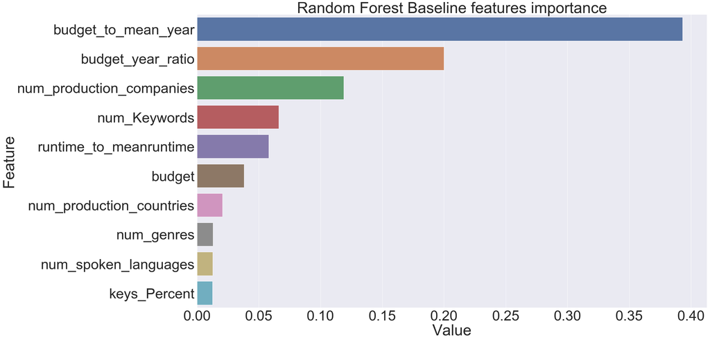

```
|   iter    |  target   | max_depth | max_fe... | min_sa... | min_sa... | n_esti... |
-------------------------------------------------------------------------------------
|  1        | -2.154    |  131.3    |  0.5783   |  50.62    |  2.13     |  797.8    |
|  2        | -2.174    |  33.1     |  0.6441   |  58.14    |  13.39    |  126.9    |
|  3        | -2.27     |  127.1    |  0.2104   |  74.3     |  3.219    |  205.2    |
|  4        | -2.161    |  73.54    |  0.6013   |  53.72    |  10.61    |  607.9    |
|  5        | -2.216    |  46.22    |  0.6798   |  85.46    |  2.798    |  107.9    |
|  6        | -2.212    |  187.6    |  0.697    |  88.0     |  13.42    |  194.5    |
|  7        | -2.213    |  126.1    |  0.6091   |  89.5     |  14.3     |  595.0    |
|  8        | -2.26     |  124.5    |  0.2325   |  80.5     |  7.636    |  809.0    |
|  9        | -2.236    |  186.5    |  0.896    |  95.63    |  11.3     |  587.5    |
|  10       | -2.162    |  178.6    |  0.5202   |  53.61    |  14.81    |  200.2    |
|  11       | -2.218    |  53.72    |  0.6599   |  91.68    |  10.21    |  598.0    |
|  12       | -2.216    |  176.6    |  0.5399   |  91.44    |  14.36    |  928.9    |
|  13       | -3.321    |  1.0      |  1.0      |  50.0     |  2.0      |  1e+03    |
|  14       | -2.219    |  200.0    |  0.2      |  50.0     |  2.0      |  100.0    |
|  15       | -3.316    |  1.0      |  1.0      |  50.0     |  15.0     |  406.3    |
|  16       | -2.213    |  200.0    |  0.2      |  50.0     |  15.0     |  730.1    |
|  17       | -3.319    |  1.0      |  1.0      |  50.0     |  15.0     |  721.2    |
|  18       | -2.215    |  200.0    |  0.2      |  50.0     |  2.0      |  408.8    |
|  19       | -2.214    |  200.0    |  0.2      |  50.0     |  2.0      |  1e+03    |
|  20       | -2.214    |  200.0    |  0.2      |  50.0     |  2.0      |  857.3    |
|  21       | -2.255    |  200.0    |  1.0      |  100.0    |  2.0      |  318.1    |
|  22       | -2.181    |  200.0    |  1.0      |  50.0     |  2.0      |  530.1    |
|  23       | -2.18     |  106.3    |  1.0      |  50.0     |  15.0     |  100.0    |
|  24       | -2.257    |  200.0    |  1.0      |  100.0    |  2.0      |  1e+03    |
|  25       | -3.669    |  1.0      |  0.2      |  50.0     |  2.0      |  100.0    |
|  26       | -3.32     |  1.0      |  1.0      |  100.0    |  15.0     |  224.7    |
|  27       | -2.333    |  118.7    |  0.2      |  100.0    |  2.0      |  477.4    |
|  28       | -3.649    |  1.0      |  0.2      |  50.0     |  2.0      |  539.5    |
|  29       | -2.256    |  116.8    |  1.0      |  100.0    |  2.0      |  693.3    |
|  30       | -2.255    |  200.0    |  1.0      |  100.0    |  15.0     |  466.1    |
|  31       | -2.255    |  89.95    |  1.0      |  100.0    |  15.0     |  145.2    |
|  32       | -2.214    |  119.7    |  0.2      |  50.0     |  15.0     |  327.1    |
|  33       | -3.63     |  1.0      |  0.2      |  100.0    |  2.0      |  867.7    |
|  34       | -2.256    |  200.0    |  1.0      |  100.0    |  2.0      |  788.0    |
|  35       | -2.181    |  200.0    |  1.0      |  50.0     |  2.0      |  640.3    |
|  36       | -2.331    |  113.9    |  0.2      |  100.0    |  15.0     |  1e+03    |
|  37       | -2.214    |  200.0    |  0.2      |  50.0     |  2.0      |  277.9    |
|  38       | -2.179    |  70.62    |  1.0      |  50.0     |  2.0      |  165.2    |
|  39       | -2.255    |  127.7    |  1.0      |  100.0    |  15.0     |  384.9    |
|  40       | -2.182    |  119.9    |  1.0      |  50.0     |  2.0      |  912.7    |
|  41       | -2.34     |  200.0    |  0.2      |  100.0    |  15.0     |  100.0    |
|  42       | -2.329    |  200.0    |  0.2      |  100.0    |  15.0     |  681.7    |
=====================================================================================
The rmse of bayesian optimize random forest is : 1.5475257516302503
```

```python
rf = RandomForestRegressor(n_estimators=50, random_state=123)
rf.fit(X_train, y_train)
y_pred = rf.predict(X_test)
print('The rmse of Random Forest Baseline is :', sqrt(mean_squared_error(y_test, y_pred)))
random_forest_after = sqrt(mean_squared_error(y_test, y_pred))

feature_imp = pd.DataFrame(sorted(zip(rf.feature_importances_,X_train.columns)),
                               columns=['Value','Feature'])
plt.figure(figsize=(40, 20))
sns.set(font_scale = 5)
sns.barplot(x="Value", y="Feature", data=feature_imp.sort_values(by="Value",
                                                        ascending=False)[0:10])
plt.title('Random Forest Baseline features importance')
plt.tight_layout()
plt.savefig('feaimp_rf.png')
plt.show()
del feature_imp

#Bayesian optimization
def bayesian_optimization(dataset, function, parameters):


    X_train, y_train, X_test, y_test = dataset
    n_iterations = 30
    gp_params = {"alpha": 1e-4}
    init_points = 12

    BO = BayesianOptimization(function, parameters)
    BO.maximize(n_iter=n_iterations, **gp_params, init_points = init_points)

    return BO.max

## for randomforest
def rfc_optimization(cv_splits):
    def function(n_estimators, max_depth, min_samples_split, max_features, min_samples_leaf): # make changes here to add more parameters

        return cross_val_score(
               RandomForestRegressor(
                   n_estimators=int(max(n_estimators,0)),
                   max_depth=int(max(max_depth,1)),
                   min_samples_split=int(max(min_samples_split,2)),
                   max_features = float(max(max_features,0.2)),
                   min_samples_leaf= int(max(min_samples_leaf,50)),
                   #oob_score = True,


                   n_jobs=-1,
                   random_state=22
                   ),
               X=X_train,
               y=y_train,
               cv=cv_splits,
               scoring="neg_mean_squared_error",
               n_jobs=-1).mean()

    parameters = {"n_estimators": (100, 1000),
                  "max_depth": (1, 200), #quick note : consider 1 to 200 next time
                  "min_samples_split": (2, 15),
                  "max_features": (0.2, 1),
                  "min_samples_leaf": (50, 100),
                  #"oob_score": True

                 }

    return function, parameters

#Train model using optimum parameters
def rftrain(X_train, y_train, X_test, y_test, function, parameters):
    dataset = (X_train, y_train, X_test, y_test)
    cv_splits = 10

    best_solution = bayesian_optimization(dataset, function, parameters)
    params = best_solution["params"]

    model = RandomForestRegressor(
             n_estimators=int(max(params["n_estimators"], 0)),
             max_depth=int(max(params["max_depth"], 1)),
             min_samples_split=int(max(params["min_samples_split"], 2)),
             max_features = float(max(params["max_features"], 0.2)),
             min_samples_leaf= int(max(params["min_samples_leaf"],50)),
             n_jobs=-1,
             random_state=23,
             #oob_score = True
             )

    model.fit(X_train, y_train)

    return model


rffunc, rfparams = rfc_optimization(10)
rfmodel = rftrain(X_train, y_train, X_test, y_test, rffunc, rfparams)



y_pred = rfmodel.predict(X_test)
print('The rmse of bayesian optimize random forest is :', sqrt(mean_squared_error(y_test, y_pred)))
opt_random_forest_after = sqrt(mean_squared_error(y_test, y_pred))
```

### 6.2.3 XGBoost

```python
model = xgb.XGBRegressor()
model.fit(X_train, y_train)
y_pred = model.predict(X_test)
print('The rmse of XGBoost Baseline:', sqrt(mean_squared_error(y_test, y_pred)))
xgb_after = sqrt(mean_squared_error(y_test, y_pred))
eval_set = [(X_test, y_test)]
def xgb_optimization(cv_splits, eval_set):
    def function(eta, gamma, max_depth,n_estimators,min_child_weight):
            return cross_val_score(
                   xgb.XGBRegressor(
                       n_estimators=int(max(n_estimators,50)),
                       objective="reg:linear",
                       learning_rate=max(eta, 0),
                       gamma=max(gamma, 0),
                       max_depth=max(int(max_depth), 1),
                       min_child_weight=max(min_child_weight, 1),
                       #subsample = max(subsample, 0),
                       #colsample_bytree = max(colsample_bytree, 0),
                       #colsample_bylevel = max(colsample_bylevel, 0),

                       seed=42,
                       nthread=-1
                       ),
                   X=X_train,
                   y=y_train,
                   cv=cv_splits,
                   scoring='neg_mean_squared_error',
                   fit_params={
                        "early_stopping_rounds": 200,
                        "eval_metric": "rmse",
                        "eval_set": eval_set},
                   n_jobs=-1).mean()

    parameters = {"eta": (0.07, 0.2),
                  "gamma": (0,2),
                  "max_depth": (1, 10),
                 "min_child_weight": (1, 10),
                 #"subsample": (0,1),
                 #"colsample_bytree": (0,1),
                  "n_estimators": (50,150),
                  #"colsample_bylevel": (0,1)

                 }

    return function, parameters

#Train model using optimum parameters
def xgbtrain(X_train, y_train, X_test, y_test, function, parameters):
    dataset = (X_train, y_train, X_test, y_test)
    cv_splits = 10

    best_solution = bayesian_optimization(dataset, function, parameters)
    params = best_solution["params"]

    model = XGBRegressor(
             n_estimators=int(params["n_estimators"]),
             objective="reg:linear",
             learning_rate= params["eta"],
             gamma=int(params["gamma"]),
             max_depth=int(params["max_depth"]),
             min_child_weight=int(params["min_child_weight"]),
             #subsample=int(params["subsample"]),
             #colsample_bytree=int(params["colsample_bytree"]),
             #colsample_bylevel = int(params["colsample_bylevel"]),
             nthread=-1,
             seed=42
             )

    model.fit(X_train, y_train)

    return model


xgbfunction, xgbparameters = xgb_optimization(10, eval_set)
xgbmodel =xgbtrain(X_train, y_train, X_test, y_test, xgbfunction, xgbparameters)


y_pred = xgbmodel.predict(X_test)
print('The rmse of optimize XGBoost is :', sqrt(mean_squared_error(y_test, y_pred)))
opt_xgboost = sqrt(mean_squared_error(y_test, y_pred))
```

```
[15:07:07] WARNING: C:/Jenkins/workspace/xgboost-win64_release_0.90/src/objective/regression_obj.cu:152: reg:linear is now deprecated in favor of reg:squarederror.
The rmse of XGBoost Baseline: 1.4085339892381594
|   iter    |  target   |    eta    |   gamma   | max_depth | min_ch... | n_esti... |
-------------------------------------------------------------------------------------
|  1        | -1.833    |  0.1537   |  1.221    |  9.585    |  3.404    |  101.0    |
|  2        | -1.731    |  0.1135   |  1.186    |  4.192    |  3.1      |  118.1    |
|  3        | -1.784    |  0.1973   |  0.07878  |  3.759    |  8.11     |  63.31    |
|  4        | -1.771    |  0.07434  |  1.592    |  5.679    |  7.317    |  88.72    |
|  5        | -1.787    |  0.1386   |  0.4459   |  2.122    |  5.499    |  133.4    |
|  6        | -1.836    |  0.1686   |  1.581    |  8.047    |  2.007    |  73.56    |
|  7        | -1.794    |  0.164    |  1.837    |  7.373    |  8.835    |  116.0    |
|  8        | -1.856    |  0.1595   |  0.03777  |  8.592    |  2.437    |  90.26    |
|  9        | -1.843    |  0.1985   |  0.9814   |  9.86     |  9.744    |  96.93    |
|  10       | -1.872    |  0.1393   |  0.07636  |  8.653    |  2.363    |  136.1    |
|  11       | -1.935    |  0.1079   |  0.7968   |  2.131    |  4.649    |  100.8    |
|  12       | -2.262    |  0.1018   |  0.9341   |  1.107    |  5.267    |  64.02    |
|  13       | -1.796    |  0.2      |  2.0      |  10.0     |  10.0     |  50.0     |
|  14       | -2.199    |  0.07     |  2.0      |  1.0      |  10.0     |  150.0    |
|  15       | -1.784    |  0.07     |  0.0      |  10.0     |  10.0     |  72.98    |
|  16       | -1.963    |  0.2      |  0.0      |  10.0     |  1.0      |  58.25    |
|  17       | -1.796    |  0.2      |  2.0      |  10.0     |  10.0     |  61.46    |
|  18       | -2.211    |  0.2      |  0.0      |  1.0      |  10.0     |  50.0     |
|  19       | -1.769    |  0.07     |  2.0      |  10.0     |  10.0     |  129.7    |
|  20       | -1.92     |  0.08171  |  1.256    |  3.883    |  1.934    |  85.73    |
|  21       | -1.927    |  0.2      |  2.0      |  10.0     |  1.0      |  150.0    |
|  22       | -1.927    |  0.2      |  2.0      |  10.0     |  1.0      |  123.3    |
|  23       | -2.138    |  0.2      |  0.0      |  1.0      |  10.0     |  122.6    |
|  24       | -1.917    |  0.2      |  0.0      |  10.0     |  10.0     |  143.2    |
|  25       | -2.172    |  0.2      |  0.0      |  1.0      |  10.0     |  78.93    |
|  26       | -2.205    |  0.07     |  2.0      |  1.0      |  1.0      |  142.3    |
|  27       | -1.909    |  0.07     |  0.0      |  10.0     |  1.0      |  111.6    |
|  28       | -2.146    |  0.2      |  2.0      |  1.0      |  1.0      |  111.1    |
|  29       | -2.217    |  0.07     |  0.0      |  1.0      |  1.0      |  126.9    |
|  30       | -1.964    |  0.2      |  0.0      |  10.0     |  1.0      |  50.0     |
|  31       | -1.856    |  0.07     |  2.0      |  3.36     |  10.0     |  136.8    |
|  32       | -1.795    |  0.2      |  2.0      |  10.0     |  10.0     |  83.5     |
|  33       | -1.918    |  0.07     |  0.0      |  10.0     |  1.0      |  79.91    |
|  34       | -1.887    |  0.07     |  0.0      |  10.0     |  10.0     |  55.56    |
|  35       | -1.897    |  0.2      |  0.0      |  10.0     |  5.43     |  66.77    |
|  36       | -2.157    |  0.2      |  2.0      |  1.0      |  10.0     |  94.41    |
|  37       | -1.776    |  0.07     |  0.0      |  10.0     |  7.076    |  121.1    |
|  38       | -1.766    |  0.2      |  2.0      |  5.277    |  10.0     |  68.54    |
|  39       | -1.775    |  0.07     |  0.0      |  10.0     |  10.0     |  107.2    |
|  40       | -1.848    |  0.2      |  0.0      |  7.306    |  10.0     |  133.2    |
|  41       | -1.795    |  0.2      |  2.0      |  10.0     |  10.0     |  150.0    |
|  42       | -1.763    |  0.07     |  2.0      |  6.235    |  5.931    |  129.9    |
=====================================================================================
[15:13:10] WARNING: C:/Jenkins/workspace/xgboost-win64_release_0.90/src/objective/regression_obj.cu:152: reg:linear is now deprecated in favor of reg:squarederror.
The rmse of optimize XGBoost is : 1.286538435223141
```

### 6.2.4 Lightgbm

```python
train_set = lgb.Dataset(X_train, label=y_train)
valid_set = lgb.Dataset(X_test, label=y_test)
params = {
        "objective" : "regression",
        "metric" : "rmse",
        "num_leaves" : 100,
        "learning_rate" : 0.03,
        "bagging_fraction" : 0.9,
        "bagging_seed" : 0,
        "num_threads" : 4,
        "colsample_bytree" : 0.5,
        'min_data_in_leaf':1900,
        'min_split_gain':0.00011,
        'lambda_l2':9
}

model = lgb.train(  params,
                    train_set = train_set,
                    num_boost_round=9400,
                    early_stopping_rounds=200,
                    verbose_eval=100,
                    valid_sets=[train_set,valid_set]
                  )


y_pred=model.predict(X_test, num_iteration=model.best_iteration)
print('The rmse of Baseline lightgbm is :', sqrt(mean_squared_error(y_test, y_pred)))
lgb_after = sqrt(mean_squared_error(y_test, y_pred))

def bayesion_opt_lgbm(X, y, init_iter=12, n_iters=30, random_state=11, seed = 101, num_iterations = 200):


    dtrain = lgb.Dataset(data=X, label=y)

      # Objective Function
    def hyp_lgbm(num_leaves, feature_fraction, bagging_fraction, max_depth, min_split_gain, min_child_weight, n_estimators, learning_rate, subsample, colsample_bytree):

        params = {'application':'regression','num_iterations': num_iterations,
                         'early_stopping_round':50,
                        'metric':'l2'} # Default parameters


        params["n_estimators"] = int(max(n_estimators, 10))
        params["learning_rate"] = float(max(learning_rate, 0 ))
        params["num_leaves"] = int(round(num_leaves))
        params['feature_fraction'] = max(min(feature_fraction, 1), 0)
        params['bagging_fraction'] = max(min(bagging_fraction, 1), 0)
        params['max_depth'] = int(round(max_depth))
        params['min_split_gain'] = min_split_gain
        params['min_child_weight'] = min_child_weight
        params['subsample'] = max(subsample, 0)
        params['colsample_bytree'] = max(colsample_bytree, 0)





        cv_results = lgb.cv(params, dtrain, nfold=5, seed=seed, stratified=False,
                                  verbose_eval =None, metrics=['l2'])
              # print(cv_results)
        return -np.min(cv_results['l2-mean'])


      # Domain space-- Range of hyperparameters
    pds = {     'num_leaves': (10, 100),
                'feature_fraction': (0.1, 0.9),
                'bagging_fraction': (0.8, 1),
                'max_depth': (1, 2000),
                'min_split_gain': (0.001, 0.1),
                'min_child_weight': (10, 25),
                'n_estimators' : (10,10000),
                "learning_rate": (0.001, 0.4),
                "subsample": (0, 1),
                "colsample_bytree" : (0, 1)

                }

      # Surrogate model
    optimizer = BayesianOptimization(hyp_lgbm, pds, random_state=random_state)

      # Optimize
    optimizer.maximize(init_points=init_iter, n_iter=n_iters)
    return optimizer.max

opt_params = bayesion_opt_lgbm(X, y, init_iter=12, n_iters=30, random_state=77, seed = 101, num_iterations = 200)

opt_params

# create dataset for lightgbm
lgb_train = lgb.Dataset(X_train, y_train)
lgb_eval = lgb.Dataset(X_test, y_test, reference=lgb_train)

# specify your configurations as a dict

params =  {'bagging_fraction': 1.0,
  'colsample_bytree': 1.0,
  'feature_fraction': 0.9,
  'learning_rate': 0.4,
  'max_depth': 2000,
  'min_child_weight': 10.0,
  'min_split_gain': 0.1,
  'n_estimators': 10000.0,
  'num_leaves': 10,
  'subsample': 0.0}


print('Starting training...')
# train
gbm = lgb.train(params,
                lgb_train,
                num_boost_round=500,
                valid_sets=lgb_eval)



print('Starting predicting...')
# predict
y_pred = gbm.predict(X_test, num_iteration=gbm.best_iteration)
# eval
print('The rmse of optimize lightgbm is :', sqrt(mean_squared_error(y_test, y_pred)))
opt_lgb_after = sqrt(mean_squared_error(y_test, y_pred))
```

```
Training until validation scores don't improve for 200 rounds.
[100]	training's rmse: 1.80792	valid_1's rmse: 1.81231
[200]	training's rmse: 1.76964	valid_1's rmse: 1.81079
[300]	training's rmse: 1.76534	valid_1's rmse: 1.81659
Early stopping, best iteration is:
[142]	training's rmse: 1.78146	valid_1's rmse: 1.80675
The rmse of Baseline lightgbm is : 1.8067465267745138
|   iter    |  target   | baggin... | colsam... | featur... | learni... | max_depth | min_ch... | min_sp... | n_esti... | num_le... | subsample |
-------------------------------------------------------------------------------------------------------------------------------------------------
```

```
|  1        | -1.875    |  0.9838   |  0.6422   |  0.703    |  0.05659  |  175.6    |  21.82    |  0.03329  |  5.415e+0 |  31.62    |  0.5454   |
```

```
|  2        | -1.907    |  0.8801   |  0.7152   |  0.7693   |  0.2358   |  593.0    |  14.22    |  0.07085  |  4.232e+0 |  15.16    |  0.747    |
```

```
|  3        | -1.954    |  0.8905   |  0.1758   |  0.1395   |  0.1177   |  134.5    |  21.27    |  0.007313 |  4.325e+0 |  42.78    |  0.152    |
```

```
|  4        | -2.065    |  0.9093   |  0.4433   |  0.1288   |  0.3293   |  547.3    |  12.53    |  0.06479  |  1.084e+0 |  41.79    |  0.3857   |
```

```
|  5        | -1.867    |  0.8891   |  0.9771   |  0.6835   |  0.1256   |  1.79e+03 |  21.75    |  0.02694  |  3.102e+0 |  21.65    |  0.4222   |
```

```
|  6        | -1.952    |  0.988    |  0.367    |  0.4478   |  0.3669   |  1.895e+0 |  13.82    |  0.07126  |  509.3    |  22.13    |  0.5065   |
```

```
|  7        | -1.913    |  0.9178   |  0.3269   |  0.2159   |  0.1038   |  1.715e+0 |  20.26    |  0.09986  |  3.201e+0 |  50.81    |  0.8676   |
```

```
|  8        | -1.873    |  0.9277   |  0.3319   |  0.5336   |  0.04582  |  1.633e+0 |  13.31    |  0.05198  |  5.266e+0 |  34.94    |  0.9044   |
```

```
|  9        | -1.861    |  0.8841   |  0.949    |  0.7292   |  0.1931   |  24.83    |  10.9     |  0.08275  |  4.052e+0 |  14.78    |  0.2596   |
```

```
|  10       | -1.913    |  0.8562   |  0.9433   |  0.8149   |  0.08171  |  201.6    |  18.6     |  0.07479  |  6.012e+0 |  91.83    |  0.9386   |
```

```
|  11       | -1.904    |  0.9123   |  0.8908   |  0.35     |  0.3087   |  428.1    |  14.33    |  0.02807  |  2.493e+0 |  11.3     |  0.6091   |
```

```
|  12       | -1.902    |  0.9724   |  0.2591   |  0.7935   |  0.1712   |  321.6    |  10.85    |  0.04286  |  7.363e+0 |  52.93    |  0.7007   |
```

```
|  13       | -1.901    |  1.0      |  1.0      |  0.9      |  0.4      |  2e+03    |  10.0     |  0.1      |  1e+04    |  10.0     |  0.0      |
```

```
|  14       | -2.08     |  1.0      |  1.0      |  0.9      |  0.4      |  1.0      |  10.0     |  0.1      |  1e+04    |  10.0     |  1.0      |
```

```
|  15       | -1.901    |  1.0      |  1.0      |  0.9      |  0.4      |  2e+03    |  10.0     |  0.001    |  7.761e+0 |  10.0     |  0.0      |
```

```
|  16       | -2.08     |  0.8      |  1.0      |  0.9      |  0.4      |  1.0      |  10.0     |  0.001    |  10.0     |  10.0     |  0.0      |
```

```
|  17       | -1.933    |  1.0      |  1.0      |  0.3681   |  0.4      |  2e+03    |  10.0     |  0.06682  |  1.792e+0 |  10.0     |  1.0      |
```

```
|  18       | -1.901    |  1.0      |  1.0      |  0.9      |  0.4      |  1.078e+0 |  10.0     |  0.1      |  8.868e+0 |  10.0     |  1.0      |
```

```
|  19       | -5.642    |  1.0      |  1.0      |  0.1      |  0.001    |  2e+03    |  10.0     |  0.001    |  6.399e+0 |  10.0     |  1.0      |
```

```
|  20       | -1.93     |  0.8      |  1.0      |  0.9      |  0.03889  |  2e+03    |  25.0     |  0.001    |  4.388e+0 |  10.0     |  0.0      |
```

```
|  21       | -5.635    |  0.8      |  0.0      |  0.1      |  0.001    |  2e+03    |  25.0     |  0.001    |  8.738e+0 |  100.0    |  0.0      |
```

```
|  22       | -5.635    |  0.8704   |  0.3963   |  0.1      |  0.001    |  941.5    |  25.0     |  0.07356  |  4.99e+03 |  100.0    |  0.0      |
```

```
|  23       | -1.974    |  0.9965   |  0.5772   |  0.1964   |  0.1797   |  1.643e+0 |  16.92    |  0.07218  |  5.252e+0 |  42.07    |  0.1723   |
```

```
|  24       | -4.823    |  0.8      |  0.0      |  0.9      |  0.001    |  1.534e+0 |  10.0     |  0.001    |  5.624e+0 |  10.0     |  1.0      |
```

```
|  25       | -1.872    |  0.9132   |  0.9636   |  0.8863   |  0.2472   |  314.3    |  11.16    |  0.1      |  4.106e+0 |  10.76    |  0.5602   |
```

```
|  26       | -1.886    |  0.8661   |  0.8627   |  0.7817   |  0.06402  |  144.5    |  19.86    |  0.07943  |  5.711e+0 |  62.3     |  0.8583   |
```

```
|  27       | -1.883    |  0.9461   |  0.2799   |  0.2079   |  0.3105   |  446.0    |  19.6     |  0.001    |  5.747e+0 |  10.0     |  0.0      |
```

```
|  28       | -4.87     |  1.0      |  0.08787  |  0.4814   |  0.001    |  550.2    |  10.0     |  0.1      |  6.074e+0 |  100.0    |  0.6691   |
```

```
|  29       | -1.919    |  0.8473   |  0.0      |  0.9      |  0.02401  |  374.9    |  10.0     |  0.001    |  5.542e+0 |  100.0    |  1.0      |
```

```
|  30       | -2.079    |  0.8      |  1.0      |  0.9      |  0.4      |  1.0      |  25.0     |  0.001    |  5.948e+0 |  10.0     |  0.0      |
```

```
|  31       | -2.009    |  1.0      |  1.0      |  0.9      |  0.4      |  410.6    |  10.0     |  0.1      |  4.436e+0 |  100.0    |  1.0      |
```

```
|  32       | -5.635    |  0.8      |  0.0      |  0.1      |  0.001    |  208.0    |  25.0     |  0.001    |  3.797e+0 |  100.0    |  1.0      |
```

```
|  33       | -1.917    |  0.8155   |  0.06485  |  0.437    |  0.3404   |  368.6    |  10.32    |  0.009219 |  4.261e+0 |  10.9     |  0.3136   |
```

```
|  34       | -2.934    |  0.8051   |  0.9985   |  0.9      |  0.004336 |  1.96e+03 |  10.0     |  0.006686 |  3.293e+0 |  10.07    |  0.00248  |
```

```
|  35       | -1.98     |  1.0      |  0.6774   |  0.3635   |  0.2223   |  1.575e+0 |  25.0     |  0.1      |  2.993e+0 |  55.81    |  1.0      |
```

```
|  36       | -5.633    |  0.9457   |  0.0      |  0.1      |  0.001    |  1.805e+0 |  10.0     |  0.1      |  2.827e+0 |  100.0    |  0.3177   |
```

```
|  37       | -1.901    |  1.0      |  0.0      |  0.9      |  0.4      |  259.6    |  10.0     |  0.001    |  5.837e+0 |  10.0     |  0.0      |
```

```
|  38       | -1.924    |  0.8      |  1.0      |  0.9      |  0.4      |  1.479e+0 |  25.0     |  0.001    |  3.164e+0 |  10.0     |  0.0      |
```

```
|  39       | -2.08     |  1.0      |  0.1663   |  0.9      |  0.4      |  1.0      |  10.0     |  0.001    |  5.524e+0 |  100.0    |  0.0      |
```

```
|  40       | -5.635    |  1.0      |  0.192    |  0.1      |  0.001    |  1.33e+03 |  25.0     |  0.1      |  2.991e+0 |  100.0    |  1.0      |
```

```
|  41       | -1.911    |  0.9689   |  0.2283   |  0.7389   |  0.3241   |  239.4    |  13.15    |  0.08378  |  5.607e+0 |  10.66    |  0.3545   |
```

```
|  42       | -2.009    |  1.0      |  1.0      |  0.9      |  0.4      |  157.0    |  10.0     |  0.1      |  4.164e+0 |  100.0    |  1.0      |
=================================================================================================================================================
Starting training...
```

```
Starting predicting...
The rmse of optimize lightgbm is : 1.0871824776709447
```

Lets see if we can improve results using simple ensembling techniques

```python
#Top Models
print("Random Forest Baseline :", random_forest_after)
print("Optimize Lightgbm :", opt_lgb_after)
opt_lightgbm = y_pred   #1.09
random_forest_base = rf.predict(X_test) #0.95

def ensembling(model1_prediction, model2_prediction):
    for weight1 in np.arange(0,1,0.05):
        smallest = 100
        tmp10 = (weight1 * model1_prediction) + ((1-weight1) * model2_prediction)
        result = sqrt(mean_squared_error(y_test, tmp10))
        if result < smallest:
            smallest = result
            wt1 = weight1
            wt2 = (1-weight1)
    return smallest, wt1, wt2


best_rmse, rf_weight, gbm_weight =ensembling(random_forest_base, opt_lightgbm)
print ("RMSE by ensembling top individual models: ", best_rmse)
```

```
Random Forest Baseline : 0.9657733818894055
Optimize Lightgbm : 1.0871824776709447
RMSE by ensembling top individual models:  0.9653926380624933
```

# 7.Summary of Models

For all the models the metric is Root Mean Squared Logarithmic Error (RMSLE)

[figure not shown]

in above plot we are looking at the feature importance of our best model when we have zeros in our target variable

[figure not shown]

In the above plot we are looking at the feature importance of our best model when we have replaced zeros in our target variable

# 8. Conclusion

we have started this project by imputing missing values, creating new features, eliminating non-significant features and finally we have trained various machine learning model. we have about 1500 zero values in our target variable which makes the data noisy. we can clearly observe the increment in the performance of the models when noised was removed.

Best Model performance with zero values in Target is : 5.331 (RMSLE)  
Best Model performance with filled zero values in Target is : 0.96 (RMSLE)

we have seen that the features like budget, number of production country involve, number of spoken languages, number of keywords, number of genres are most important in explaining our target variable (Revenue)

# Thank You

```python
!jupyter nbconvert Movie_Revenue_Prediction.ipynb --to pdf
```

[output not shown]